# Linear Regression in R

## Fish Weight Prediction

This dataset is a record of 7 common different fish species in fish market sales. With this dataset, a predictive model can be performed using machine friendly data and estimate the weight of fish can be predicted.

### Data Exploration

First input and see the structure of the dataset:

```r
data_fish <-  read.csv("Fish.csv")
names(data_fish)[1] = "Species"
str(data_fish)
```

```
## 'data.frame':    159 obs. of  7 variables:
##  $ Species: Factor w/ 7 levels "Bream","Parkki",..: 1 1 1 1 1 1 1 1 1 1 ...
##  $ Weight : num  242 290 340 363 430 450 500 390 450 500 ...
##  $ Length1: num  23.2 24 23.9 26.3 26.5 26.8 26.8 27.6 27.6 28.5 ...
##  $ Length2: num  25.4 26.3 26.5 29 29 29.7 29.7 30 30 30.7 ...
##  $ Length3: num  30 31.2 31.1 33.5 34 34.7 34.5 35 35.1 36.2 ...
##  $ Height : num  11.5 12.5 12.4 12.7 12.4 ...
##  $ Width  : num  4.02 4.31 4.7 4.46 5.13 ...
```

To do the linear regression in this dataset, the Species feature need to convert to dummy variables. Structure after dummy:

```r
data_fish = dummy_cols(data_fish)
data_fish = data_fish[,-1]
str(data_fish)
```

```
## 'data.frame':    159 obs. of  13 variables:
##  $ Weight           : num  242 290 340 363 430 450 500 390 450 500 ...
##  $ Length1          : num  23.2 24 23.9 26.3 26.5 26.8 26.8 27.6 27.6 28.5 ...
##  $ Length2          : num  25.4 26.3 26.5 29 29 29.7 29.7 30 30 30.7 ...
##  $ Length3          : num  30 31.2 31.1 33.5 34 34.7 34.5 35 35.1 36.2 ...
##  $ Height           : num  11.5 12.5 12.4 12.7 12.4 ...
##  $ Width            : num  4.02 4.31 4.7 4.46 5.13 ...
##  $ Species_Bream    : int  1 1 1 1 1 1 1 1 1 1 ...
##  $ Species_Parkki   : int  0 0 0 0 0 0 0 0 0 0 ...
##  $ Species_Perch    : int  0 0 0 0 0 0 0 0 0 0 ...
##  $ Species_Pike     : int  0 0 0 0 0 0 0 0 0 0 ...
##  $ Species_Roach    : int  0 0 0 0 0 0 0 0 0 0 ...
##  $ Species_Smelt    : int  0 0 0 0 0 0 0 0 0 0 ...
##  $ Species_Whitefish: int  0 0 0 0 0 0 0 0 0 0 ...
```

### Missing values

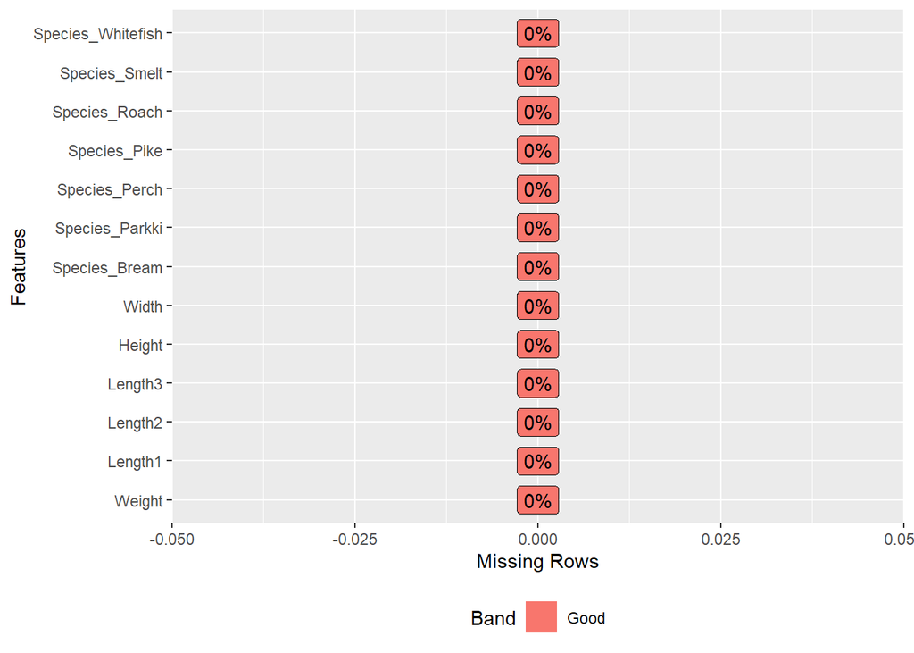

```r
plot_missing(data_fish)
```

It is good that, the dataset is not have missing values.

### Correlation

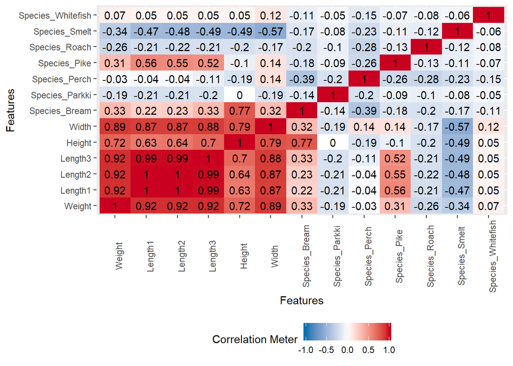

```r
plot_correlation(data_fish)
```

From the plot, it show that the Length 1, Length 2, Length 3, Height and Width feature have a high correlation on the Weight feature

### Stratified sampling

The sampling will divide the dataset so that 70% instanses of the dataset will go for training and 30% will go for validating

```r
str(training_set)
```

```
## 'data.frame':    111 obs. of  13 variables:
##  $ Weight           : num  242 340 450 500 450 500 500 500 340 600 ...
##  $ Length1          : num  23.2 23.9 26.8 26.8 27.6 28.5 28.7 29.1 29.5 29.4 ...
##  $ Length2          : num  25.4 26.5 29.7 29.7 30 30.7 31 31.5 32 32 ...
##  $ Length3          : num  30 31.1 34.7 34.5 35.1 36.2 36.2 36.4 37.3 37.2 ...
##  $ Height           : num  11.5 12.4 13.6 14.2 14 ...
##  $ Width            : num  4.02 4.7 4.93 5.28 4.84 ...
##  $ Species_Bream    : int  1 1 1 1 1 1 1 1 1 1 ...
##  $ Species_Parkki   : int  0 0 0 0 0 0 0 0 0 0 ...
##  $ Species_Perch    : int  0 0 0 0 0 0 0 0 0 0 ...
##  $ Species_Pike     : int  0 0 0 0 0 0 0 0 0 0 ...
##  $ Species_Roach    : int  0 0 0 0 0 0 0 0 0 0 ...
##  $ Species_Smelt    : int  0 0 0 0 0 0 0 0 0 0 ...
##  $ Species_Whitefish: int  0 0 0 0 0 0 0 0 0 0 ...
```

```r
str(test_set)
```

```
## 'data.frame':    48 obs. of  13 variables:
##  $ Weight           : num  290 363 430 390 475 600 650 575 685 680 ...
##  $ Length1          : num  24 26.3 26.5 27.6 28.4 29.4 31 31.3 31.4 31.8 ...
##  $ Length2          : num  26.3 29 29 30 31 32 33.5 34 34 35 ...
##  $ Length3          : num  31.2 33.5 34 35 36.2 37.2 38.7 39.5 39.2 40.6 ...
##  $ Height           : num  12.5 12.7 12.4 12.7 14.3 ...
##  $ Width            : num  4.31 4.46 5.13 4.69 5.1 ...
##  $ Species_Bream    : int  1 1 1 1 1 1 1 1 1 1 ...
##  $ Species_Parkki   : int  0 0 0 0 0 0 0 0 0 0 ...
##  $ Species_Perch    : int  0 0 0 0 0 0 0 0 0 0 ...
##  $ Species_Pike     : int  0 0 0 0 0 0 0 0 0 0 ...
##  $ Species_Roach    : int  0 0 0 0 0 0 0 0 0 0 ...
##  $ Species_Smelt    : int  0 0 0 0 0 0 0 0 0 0 ...
##  $ Species_Whitefish: int  0 0 0 0 0 0 0 0 0 0 ...
```

### Linear Regression Model

```r
regressor = lm(formula = Weight ~ .,
               data = training_set)
summary(regressor)
```

```
##
## Call:
## lm(formula = Weight ~ ., data = training_set)
##
## Residuals:
##     Min      1Q  Median      3Q     Max
## -212.91  -50.47  -14.23   38.31  259.06
##
## Coefficients: (1 not defined because of singularities)
##                   Estimate Std. Error t value Pr(>|t|)
## (Intercept)       -784.257     83.628  -9.378 2.49e-15 ***
## Length1            -62.917     42.230  -1.490  0.13943
## Length2             84.244     56.089   1.502  0.13629
## Length3             13.289     38.006   0.350  0.72734
## Height              11.584     17.621   0.657  0.51244
## Width              -12.019     29.684  -0.405  0.68643
## Species_Bream      -98.448    120.898  -0.814  0.41742
## Species_Parkki      62.615     74.270   0.843  0.40122
## Species_Perch       13.938     66.211   0.211  0.83370
## Species_Pike      -293.897     99.658  -2.949  0.00398 **
## Species_Roach       -7.001     55.613  -0.126  0.90007
## Species_Smelt      311.482     74.028   4.208 5.68e-05 ***
## Species_Whitefish       NA         NA      NA       NA
## ---
## Signif. codes:  0 '***' 0.001 '**' 0.01 '*' 0.05 '.' 0.1 ' ' 1
##
## Residual standard error: 90.9 on 99 degrees of freedom
## Multiple R-squared:  0.9449, Adjusted R-squared:  0.9388
## F-statistic: 154.3 on 11 and 99 DF,  p-value: < 2.2e-16
```

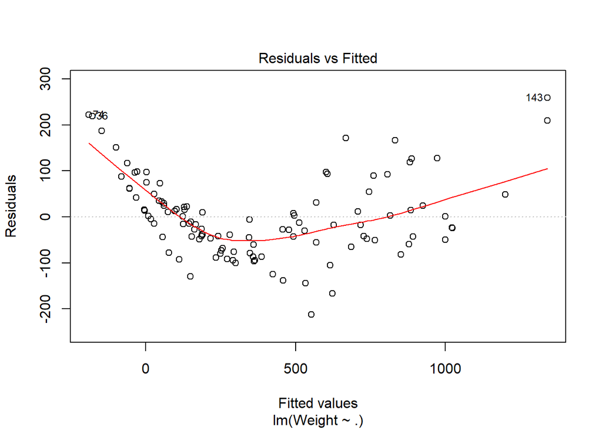

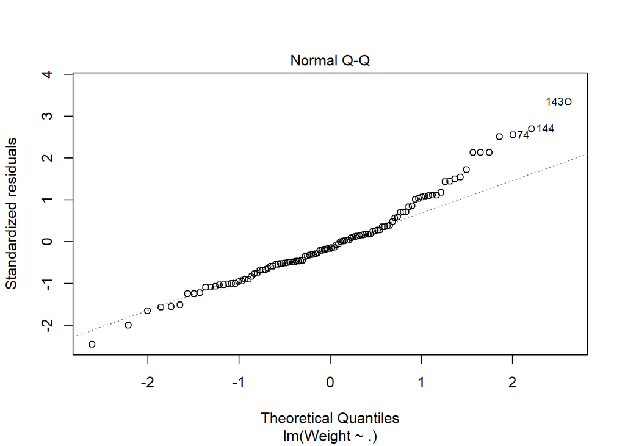

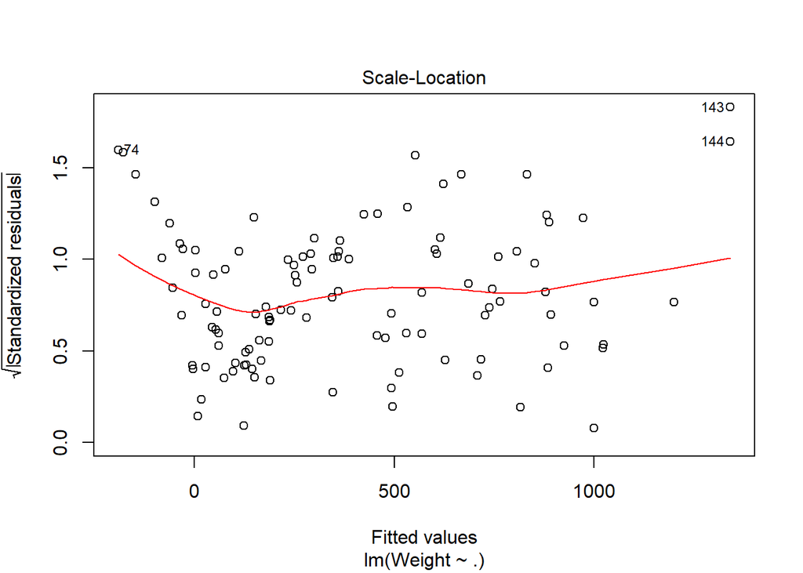

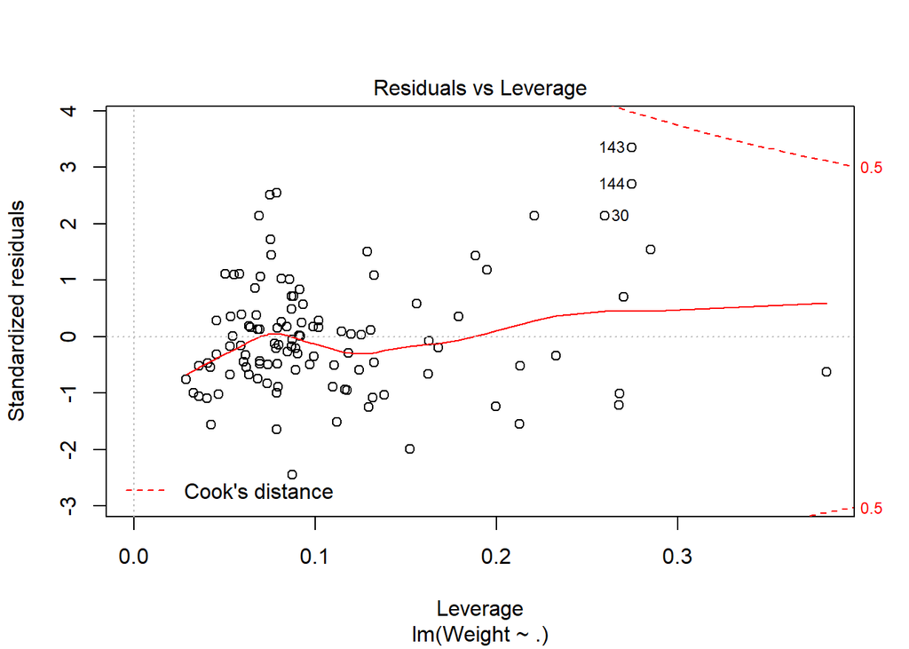

```r
plot(regressor)
```

The Residuals vs Fitted Plot show a slight parabola indicate that relationship between predictor variables and target variable (weight) maybe is slight non-linear relationship.  
The QQ Plot show that the errors is almost normally distributed.  
The Scale-Location Plot show that the residuals are spread equally along the range of predcitor.  
Residuals vs Leverage Plot show that there is no outlier that influent the regression result.

### Predicting Result

```r
pred_test <- predict(regressor, test_set)
combine_table <- cbind(pred_test,test_set$Weight)
colnames(combine_table) <- c("Prediction Weight", "Real Weight")
combine_table
```

```
##     Prediction Weight Real Weight
## 2          330.322667       290.0
## 4          444.729386       363.0
## 5          427.322380       430.0
## 8          463.600193       390.0
## 11         526.929989       475.0
## 16         569.440531       600.0
## 20         602.127787       650.0
## 21         645.489959       575.0
## 22         647.626200       685.0
## 24         710.088743       680.0
## 26         725.331985       725.0
## 31         877.757381       920.0
## 32         877.145995       955.0
## 33         905.427111       925.0
```

[output cut: 34 more lines]

```r
pred_train = predict(regressor, training_set)
rmse_train <- sqrt(mean((training_set$Weight-pred_train)^2))
rmse_test <- sqrt(mean((test_set$Weight-pred_test)^2))

rss_train <- sum((training_set$Weight-pred_train)^2)
rss_test <- sum((test_set$Weight-pred_test)^2)

tss_train <- sum((training_set$Weight - mean(training_set$Weight)) ^ 2)
tss_test <- sum((test_set$Weight - mean(test_set$Weight)) ^ 2)

r_square_train <- 1-(rss_train/tss_train)
r_square_test <- 1-(rss_test/tss_test)
```

RMSE, RSS and R² on the training set and test set:

| RMSE On training set | RMSE On test set | RSS On training set | RSS On test set | R² On training set | R² On test set |
| --- | --- | --- | --- | --- | --- |
| 85.85008 | 104.2211 | 818096.2 | 521377.6 | 0.9448807 | 0.9010514 |

### Conclusion

The R² is reached at 0.9010514, which is a good figure as it very near 1 - the maximum value of R². It show that the predicted values is highly accurate even the The Residuals vs Fitted Plot shows the slight non-linear relationship between the predictor variables and target variable.